# My Assignment Submission

## Hope it turns out fine

Here is my code for uploading the data

```r
Data1=read.csv("activity.csv", header = TRUE, sep = ",")
Data=as.data.frame(Data1)
newdata <- na.omit(Data)
```

Data Processing for Histogram and Plotting

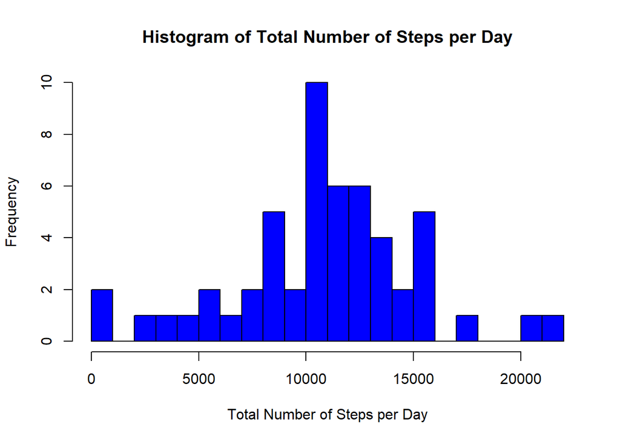

```r
Dates=as.data.frame(unique(newdata$date))
value=numeric(53)
for(i in 1:53)
{
  value[i]<- sum(newdata[newdata$date==Dates[i,1],1])
}

Steps=as.data.frame(value)


Q1= data.frame(Dates,Steps, stringsAsFactors = FALSE)
cols=c("Date","Steps")
colnames(Q1)=cols
hist(Q1$Steps, main = "Histogram of Total Number of Steps per Day",
    xlab = "Total Number of Steps per Day", ylab = "Frequency", col = "blue",
    breaks = 30)
```

```r
options(scipen=999)
Avg=mean(Q1$Steps)
Med=median(Q1$Steps)
```

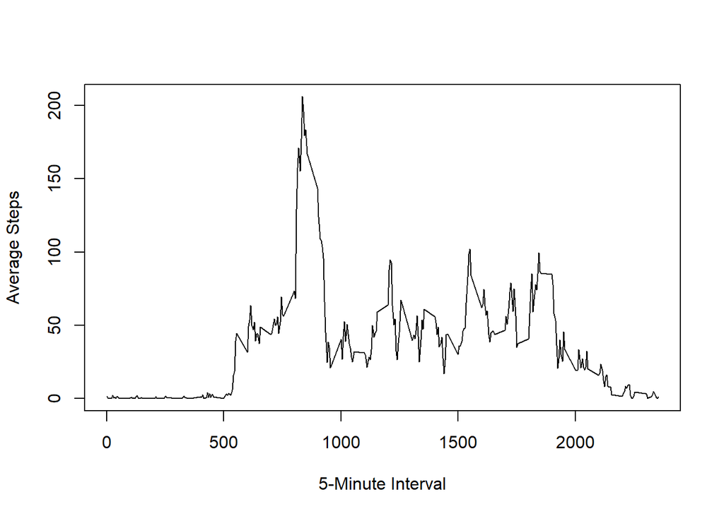

```r
Intervals=as.data.frame(unique(newdata$interval))
avginterval=numeric(288)
for(i in 1:288)
{
  avginterval[i]<- mean(newdata[newdata$interval==Intervals[i,1],1])
}

AverageInt=as.data.frame(avginterval)
x=Intervals$`unique(newdata$interval)`
y=AverageInt$avginterval
plot(x,y,type = "l", xlab = "5-Minute Interval", ylab = "Average Steps")
```

The 5-minute interval that, on average, contains the maximum number of steps

```r
Q2=data.frame(Intervals,AverageInt)
Ans2=Q2[which.max(Q2$avginterval),1]
```

The 5 minute interval which contains maximum number of steps, on average is 835  
Code to find number of rows with NA

```r
Q3=subset(Data,is.na(Data$steps))
Q3[is.na(Q3)] <- 0
Ans3=nrow(Q3)
```

The total number of missing values in the dataset (i.e. the total number of rows with NAs) are 2304  
Code to describe and show a strategy for imputing missing data

```r
mean(Data$steps, na.rm = T)
```

```
## [1] 37.3826
```

```r
Dataimpute <- Data
Dataimpute$steps[is.na(Dataimpute$steps)] <- mean(Dataimpute$steps, na.rm = T)
colSums(is.na(Dataimpute))
```

```
##    steps     date interval
##        0        0        0
```

histogram of the total number of steps taken each day

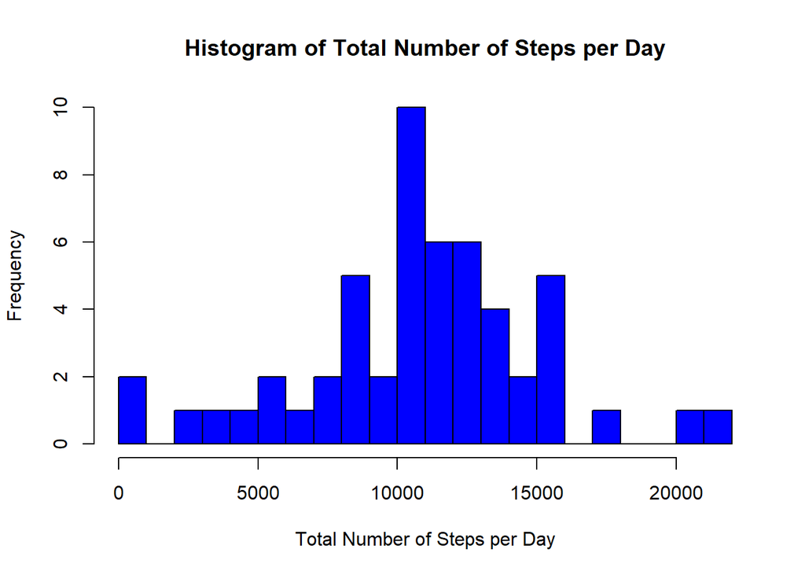

```r
value2=numeric(53)
for(i in 1:53)
{
  value2[i]<- sum(Dataimpute[Dataimpute$date==Dates[i,1],1])
}

Steps2=as.data.frame(value2)
Q4= data.frame(Dates,Steps2, stringsAsFactors = FALSE)
cols=c("Date","Steps")
colnames(Q4)=cols
hist(Q4$Steps, main = "Histogram of Total Number of Steps per Day",
    xlab = "Total Number of Steps per Day", ylab = "Frequency", col = "blue",
    breaks = 30)
```

```r
options(scipen=999)
Avg2=mean(Q4$Steps)
Med2=median(Q4$Steps)
```

```r
Dataimpute$date <- as.Date(Dataimpute$date)
Dataimpute$weekdays <- weekdays(Dataimpute$date)
Dataimpute$weeks[(Dataimpute$weekdays == "Saturday" | Dataimpute$weekdays == "Sunday")] <- "weekend"
Dataimpute$weeks[!(Dataimpute$weekdays == "Saturday" | Dataimpute$weekdays == "Sunday")] <- "weekdays"
```

```r
library(plyr)
week_comp <- ddply(Dataimpute, c("interval", "weeks"), function(x) apply(x[1],
    2, mean))
head(week_comp)
```

```
##   interval    weeks    steps
## 1        0 weekdays 7.006569
## 2        0  weekend 4.672825
## 3        5 weekdays 5.384347
## 4        5  weekend 4.672825
## 5       10 weekdays 5.139902
## 6       10  weekend 4.672825
```

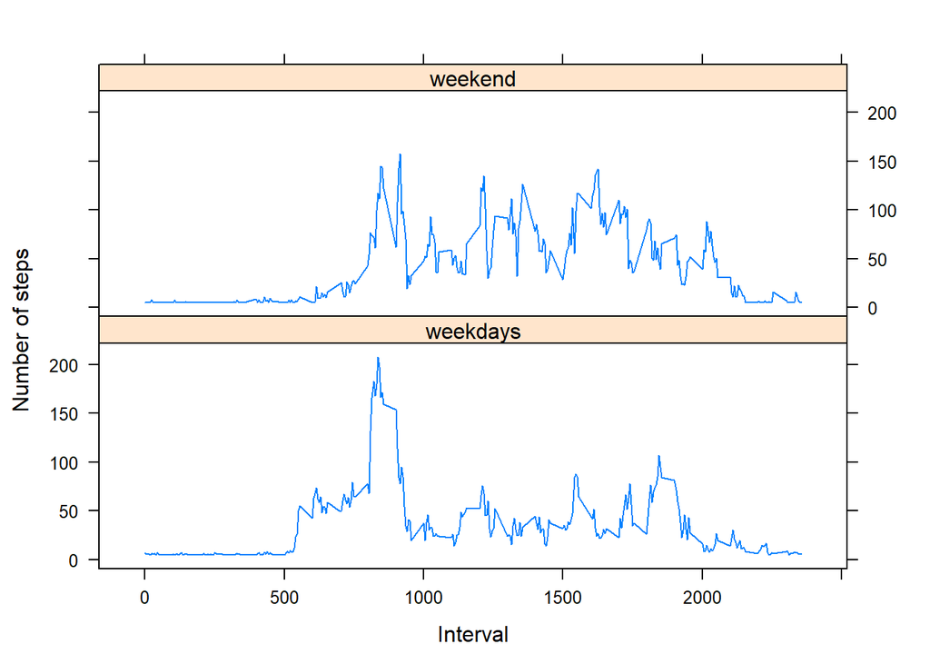

```r
library(lattice)
xyplot(steps ~ interval | weeks, data = week_comp, type = "l", xlab = "Interval",
    ylab = "Number of steps", layout = c(1, 2))
```